# Final Report

Bat speed is also included in `statcast_data`. Immediately below this note, I’ll visually examine its relationship with launch speed. Before that, some information on missingness in `launch_speed` and `bat_speed`. See Table 5 for a complete description of the missingness for bat/launch speeds for the 672,836 pitches in `statcast_data`.

Table 5: Missingness of `bat_speed` and `launch_speed`

[figure not shown]

Let’s quickly look at how the relationship between bat speed and release speed differ for fastballs and different off-speed pitches, curveballs and sliders. For comparison, I will include Figure 17 and Figure 18 beside their respective counterparts.

**Fastballs and Sliders**

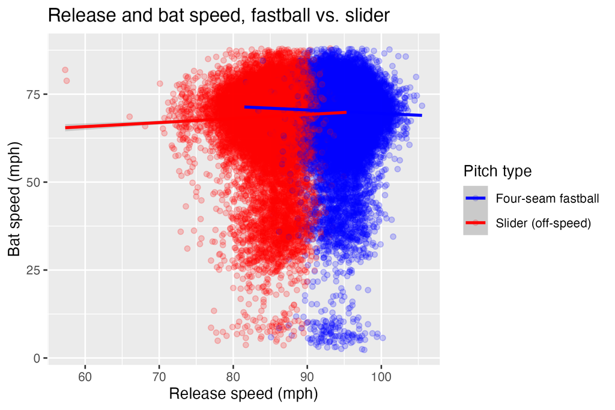

Bat speed

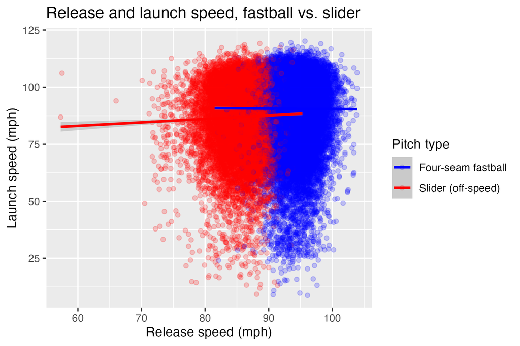

Launch speed

**Fastballs and Curveballs**

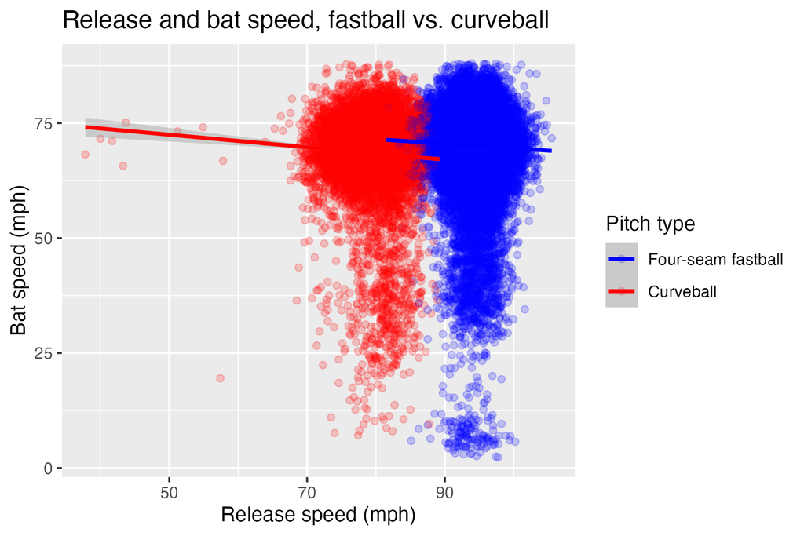

Bat speed

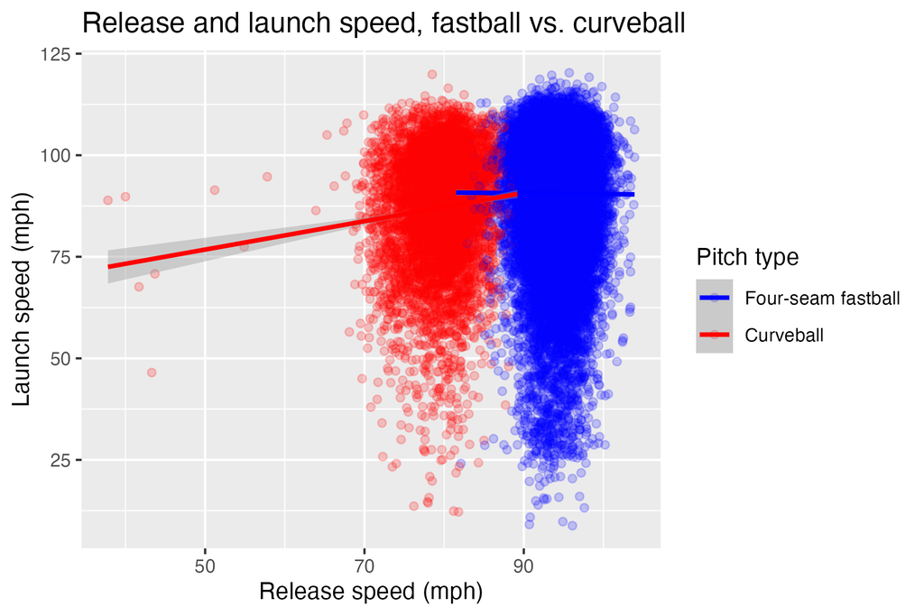

Launch speed

The most notable difference in using `bat_speed` instead of `launch_speed` is found in the fastball vs. curveball graphs, where the linear regression line for curveballs has negative slope with bat speed and positive slope with launch speed. For curveballs, an increase in release speed leads to a decrease in bat speed. Quick bat speed is advantageous against pitchers with good off-speed pitches as it allows the hitter more time to react. Perhaps this observation in the graph can be attributed to the speed at which players react to seeing a curveball. When it’s a slower curveball, they may want to wait on the pitch and gauge its movement, necessitating a quick swing to ensure good contact. Another observation that’s true for both the fastball/slider and fastball/curveball graphs: the `bat_speed` reaction to `release_speed` has a more “mushroom cloud-like” appearance than the `launch_speed` ones. Perhaps because bat speed is more constant for any given hitter than release speed? More analysis would be required to figure this one out.

#### Spray Charts

The above analysis examines the influence of a pitch’s speed on the pitch’s outcome, but I have not yet included “physical location” in my definition of outcome. Thus, I return to spray charts. How does the speed of a pitch influence where it ends up? For this analysis, I use four players to examine how pitch speed and hit location interact. The players are Shohei Ohtani (bats left), Brice Turang (bats left), Aaron Judge (bats right), and Bobby Witt Jr. (bats right).

Their four spray charts, found in Figure 20, contain the location of every batted ball, with color representing the speed class of the pitch (off-speed or fastball). I created a function similar to one I used for the platoon spray charts to produce these charts.

**Figure 20: Spray Charts by Speed Class**

**Shohei Ohtani**

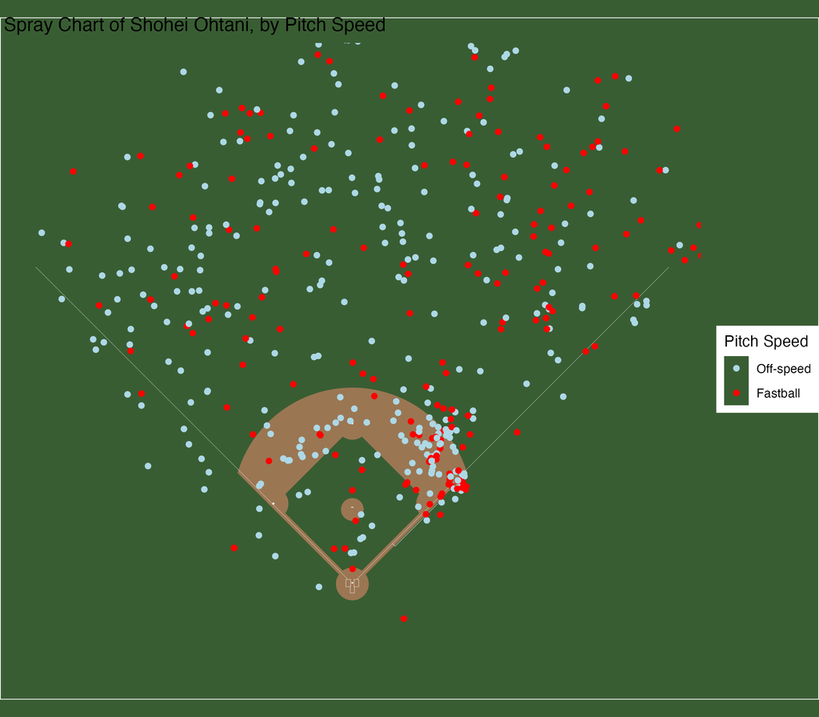

**Brice Turang**

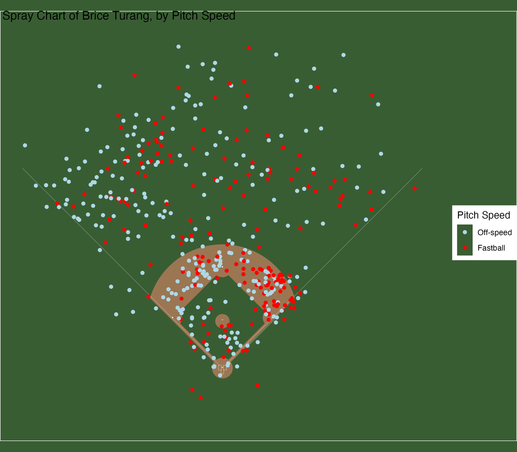

Left-handed contact hitter.

**Aaron Judge**

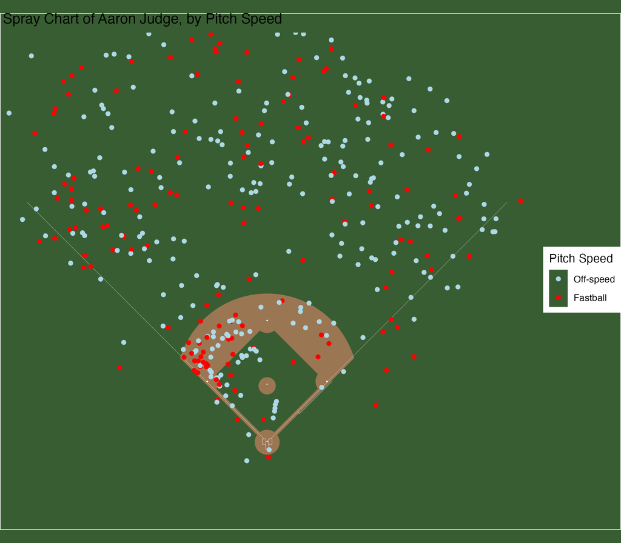

Right-handed power hitter.

**Bobby Witt Jr.**

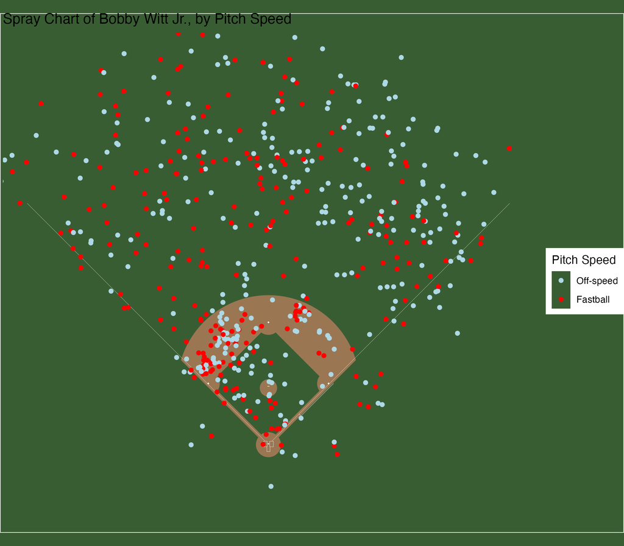

Right-handed hitter, strong in contact and power-hitting.

Each of these four hitters is unique. I made sure to pick a mixture of right- and left-handed hitters, yes, but their hitting styles differ too. Aaron Judge is a power hitter, hence the void of hits to the shallow outfield. Shohei Ohtani is a power hitter who can hit for contact. Brice Turang is a small-ball player, often leading off the Brewers lineup when facing a righthander. His infield spray is the most dense and varied. Bobby Witt Jr. is a bit of everything. He’s quick and good at contact-hitting (he bat 0.303 during the period of time this dataset covers), but he can also hit for power. His spray reflects all of this nicely.

**Figure 21: Spray Charts by Speed Class, Safe Hits Only**

**Shohei Ohtani**

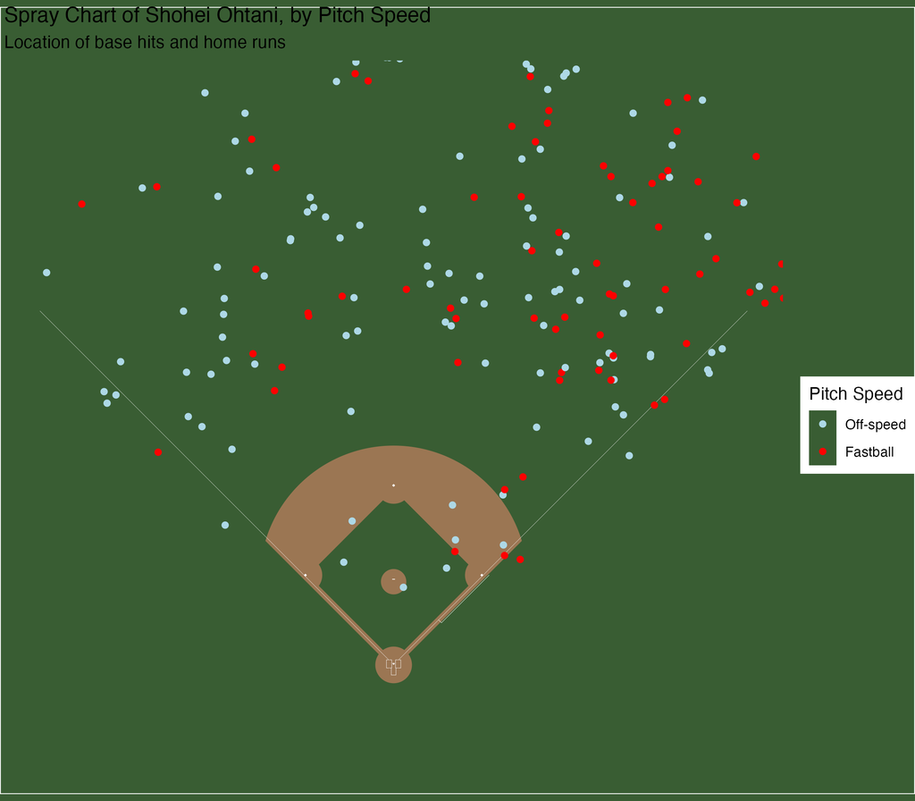

**Brice Turang**

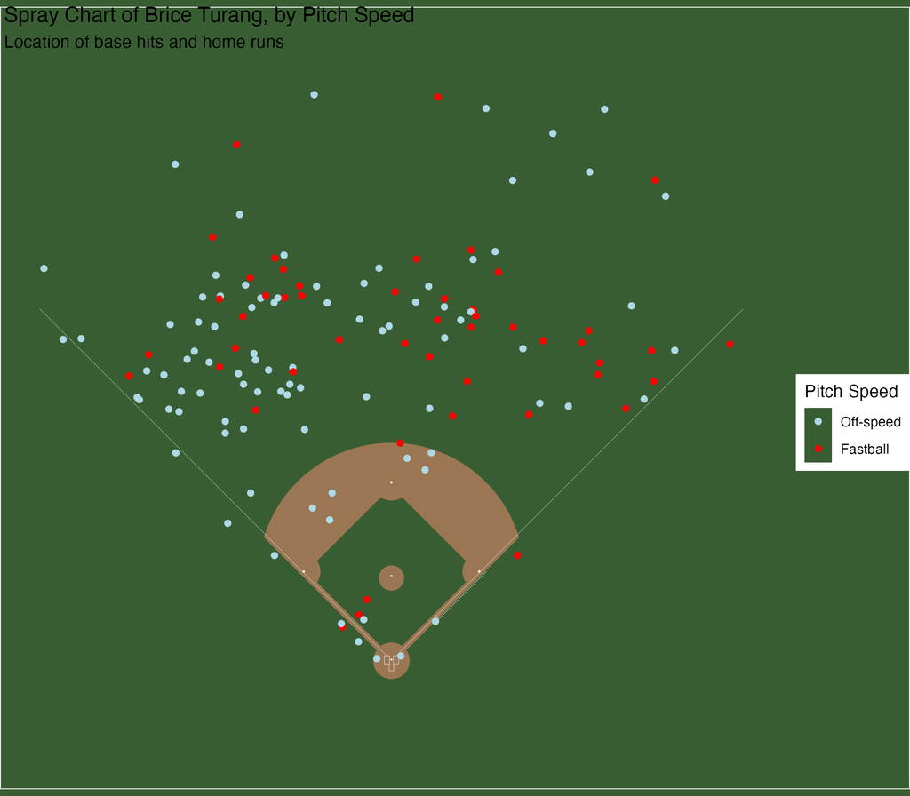

Left-handed contact hitter.

**Aaron Judge**

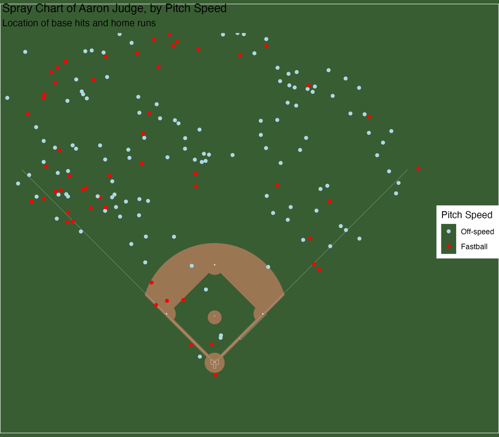

Right-handed power hitter.

**Bobby Witt Jr.**

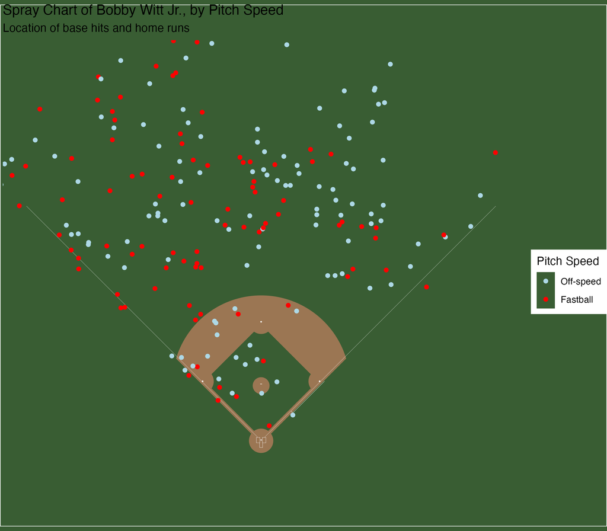

Right-handed hitter, strong in contact and power-hitting.

## Conclusions

Returning to my questions from the introduction, we now have some answers.

This conclusions section is notably sparse. I felt it was more useful to embed the conclusions within the report than try to pack everything into a final section without graphics. Please view these conclusions as brief summaries of and thoughts on the investigations/results.

First, on platoon advantage analysis. After Figure 3 and Figure 4, I was expecting the exploration to continue undermining previous assumptions that the platoon advantage is both real and significant. The spray chart analysis proved otherwise. What I found most interesting was that the platoon advantage was only clearly visible once I filtered out batted balls that resulted in outs. I had been operating under the assumption that a platoon advantage was only useful for making contact. However, it seriously contributes to the power and positioning of a hitter, as evidenced by explanation of pulling and taking a pitch opposite field. Also a revelation: one would expect switch hitters, who always have the platoon advantage, to be much better than everyone else. In fact, that was not the case. The switch hitters were good, but the one-sided hitters were quite capable of delivering. Admittedly, the players I chose for this are all high profile, in part because they are good, so perhaps there’s a clearer advantage to switch-hitting within a lower tier of play.

Second, on pitch characteristics. I was most surprised by the revelation that release speed *and* spin rate had such a small/no effect on launch speed. That seemed like a no-brainer beforehand so to be proven entirely incorrect was shocking. From the spray charts, we learned that because of baseball swing mechanics, it is easier and more common to hit home runs opposite field off of off-speed pitches. Having more time to swing is a game changer. The analysis of speed of the first pitch, second pitch, and third pitch as well as their interactions was interesting. It’s interesting how the proportion of third fastballs after two fastballs was greater than the proportion of second fastballs after one of them.

The overall results were not overly shocking. As an avid baseball fan, I have seen my fair share of statistics mappings. But I was surprised by how much good be derived from something like a spray chart. It was fascinating to pick apart each cluster of batted balls and try to figure out why it was there.

## References

Macdonald, B. (2024).*Baseball Savant pitch-level data for Major League Baseball (April 2, 2024 - October 30, 2024)* [Data set]. Connecticut Sports Analytics Symposium. [https://statds.org/events/csas2025/challenge.html.](https://statds.org/events/csas2025/challenge.html)

*MLB switch hitters (April 2, 2024 - October 30, 2024)* [Data set]. FANGRAPHS. https://www.fangraphs.com/leaders/major-league?stats=bat&lg=all&qual=0&season=2023& season1=2023&ind=0&rost=0&filter=&players=0&type=8&hand=S&team=0&startdate=2024-04-02 &enddate=2024-08-30&month=1000&pos=all&pagenum=1&pageitems=100.

Slowinski, P. (2012, April 4). *Pitch type abbreviations & classifications*. FANGRAPHS. [https://library.fangraphs.com/pitch-type-abbreviations-classifications/.](https://library.fangraphs.com/pitch-type-abbreviations-classifications/)

*Marcus Semien vs. left-handed pitchers in April 2 through October 30 2024*. statmuse. [https://www.statmuse.com/mlb/ask/marcus-semien-vs-left-handed-pitchers-in-april-2 -through-october-30-2024.](https://www.statmuse.com/mlb/ask/marcus-semien-vs-left-handed-pitchers-in-april-2%20-through-october-30-2024.)